# project2

Henry Zhao, Brian Huang, Zachary Fine

Friday, February 06, 2015

This is our second project and it’s all about earthquakes!!!  
Be ready for the data to rock your world!

```r
source("../01 Data/data.r", echo = TRUE)
```

```
##
## > library("RCurl")
```

```
##
## > earthquakes <- data.frame(eval(parse(text = substring(getURL(URLencode("http://129.152.144.84:5001/rest/native/?query=\"select * from EARTHQUAKES\"" .... [TRUNCATED]
##
## > head(earthquakes)
##                       TIME  LATITUDE LONGITUDE  DEPTH  MAG MAGTYPE  NST
## 1 2015-02-10T14:48:31.000Z -21.80240  -68.4289 133.97 4.20      mb null
## 2 2015-02-10T14:47:50.470Z   9.72760   57.5888  10.00 5.40     mww null
## 3 2015-02-10T14:44:49.360Z  41.90767 -112.3992  -0.21 0.76      md    6
## 4 2015-02-10T14:31:38.560Z  52.41580 -168.6620  34.31 4.30      mb null
## 5 2015-02-10T14:28:17.000Z  63.05790 -150.9695 122.00 2.30      ml null
## 6 2015-02-10T14:22:52.040Z -19.79390  -71.0199  12.25 4.20      mb null
##    GAP               DMIN                RMS NET         ID
## 1   64  0.754999995231628  0.720000028610229  us usc000tnnv
## 2   76   4.49300003051758  0.769999980926514  us usc000tnnx
## 3  149 0.0599999986588955 0.0799999982118607  uu uu60101507
## 4  179  0.569000005722046  0.829999983310699  us usc000tnns
## 5 null               null  0.280000001192093  ak ak11505865
## 6  151  0.866999983787537  0.660000026226044  us usc000tnnq
##                    UPDATED                         PLACE       TYPE
## 1 2015-02-10T22:51:13.037Z      90km NE of Calama, Chile earthquake
## 2 2015-02-10T22:50:29.811Z               Carlsberg Ridge earthquake
## 3 2015-02-10T20:59:44.740Z      27km NW of Garland, Utah earthquake
## 4 2015-02-10T22:34:22.511Z  59km SSE of Nikolski, Alaska earthquake
## 5 2015-02-10T15:05:32.212Z 92km NNW of Talkeetna, Alaska earthquake
## 6 2015-02-10T22:25:32.321Z   103km WNW of Iquique, Chile earthquake
```

```r
source("../02 Data Wrangling/data_wrangling.R", echo = TRUE)
```

```
##
## > require("dplyr")
```

```
##
## > require("ggplot2")
```

```
##
## > require("reshape2")
```

```
##
## > require("tidyr")
```

```
##
## > earthquakes %>% group_by(LONGITUDE) %>% summarize(avg_mag = mean(MAG)) %>%
## +     ggplot(aes(x = LONGITUDE, y = avg_mag)) + geom_density2d()
```

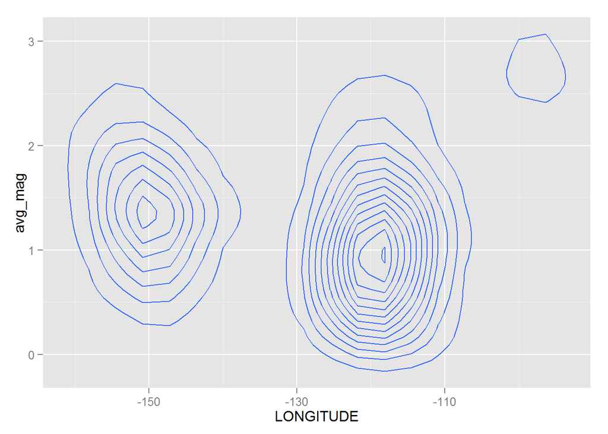

```
##
## > earthquakes %>% group_by(NST) %>% summarise(ave_mag = mean(MAG)) %>%
## +     ggplot(aes(x = NST, y = ave_mag)) + geom_point()
```

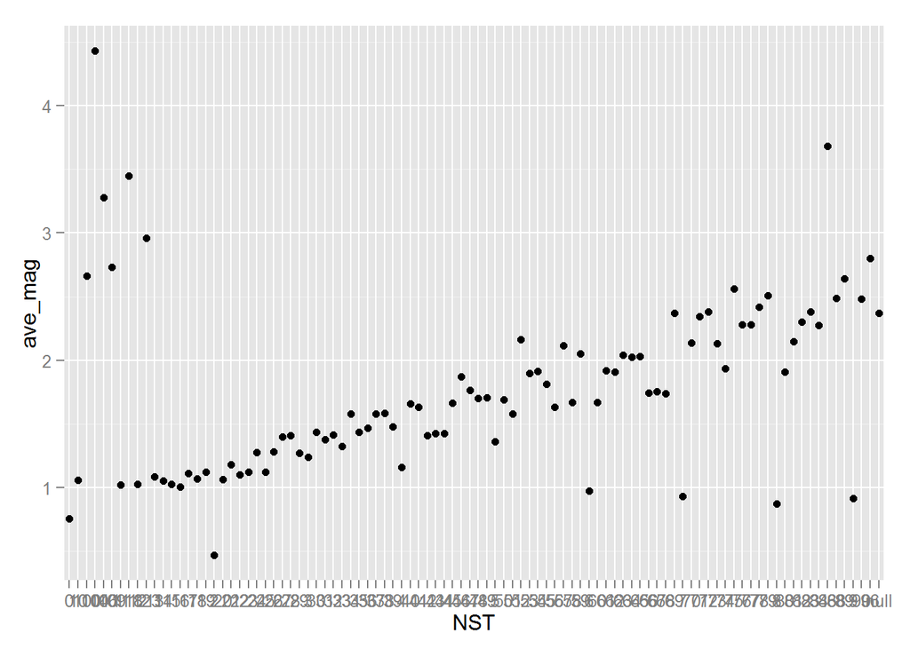

```
##
## > eq_date_group <- earthquakes %>% mutate(date = substr(TIME,
## +     1, 10)) %>% group_by(date) %>% summarize(avg_depth = mean(DEPTH),
## +     avg_mag  .... [TRUNCATED]
##
## > mdf <- melt(eq_date_group, id.vars = "date", measure.vars = c("avg_depth",
## +     "avg_mag"))
##
## > ggplot(mdf, aes(x = date, y = value, group = variable)) +
## +     geom_line(aes(color = variable))
```

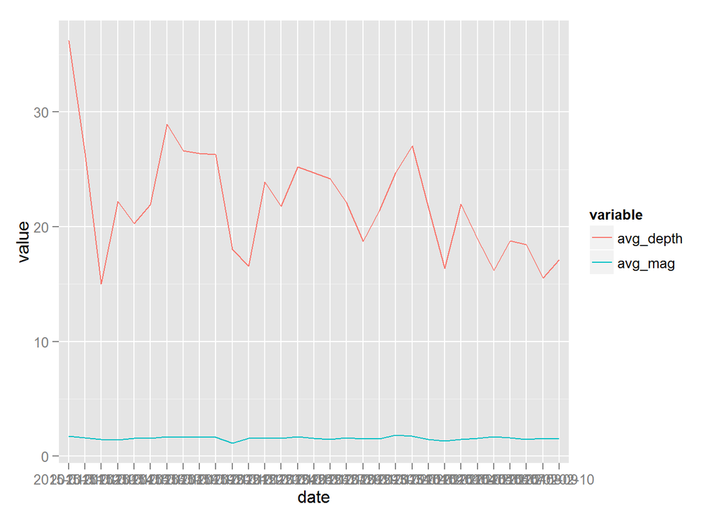

### From this project, we learned how to pipe and show the flow of our data as well as making visualizations with the data we have selected. We learned analytical skills by figuring out which data was important and how to present it in a clear format. Knowing how to pipe made our workflow more effective and less stressful.